# Biostat 203B Homework 5

Due Mar 20 @ 11:59PM

Author

Palash Raval and 406551574

## Predicting ICU duration

Using the ICU cohort `mimiciv_icu_cohort.rds` you built in Homework 4, develop at least three machine learning approaches (logistic regression with enet regularization, random forest, boosting, SVM, MLP, etc) plus a model stacking approach for predicting whether a patient’s ICU stay will be longer than 2 days. You should use the `los_long` variable as the outcome. Your algorithms can use patient demographic information (gender, age at ICU `intime`, marital status, race), ICU admission information (first care unit), the last lab measurements before the ICU stay, and first vital measurements during ICU stay as features. You are welcome to use any feature engineering techniques you think are appropriate; but make sure to not use features that are not available at an ICU stay’s `intime`. For instance, `last_careunit` cannot be used in your algorithms.

```r
library(dbplyr)
library(tidymodels)
library(tidyverse)
library(recipes)
library(ranger)
library(stacks)
```

1. Data preprocessing and feature engineering.

```r
mimiciv_icu_cohort = readRDS("../hw4/mimiciv_shiny/mimic_icu_cohort.rds")
```

```r
#removes the 14 rows with los_long being NA

mimiciv_icu_cohort = mimiciv_icu_cohort %>% filter(!is.na(los_long))

dim(mimiciv_icu_cohort)
```

```
[1] 94444    42
```

```r
mimiciv_icu_cohort$los_long = ifelse(mimiciv_icu_cohort$los_long, "YES", "NO")
```

```r
mimiciv_icu_cohort = mimiciv_icu_cohort %>%
  mutate(across(where(is.character), as.factor))
```

2. Partition data into 50% training set and 50% test set. Stratify partitioning according to `los_long`. For grading purpose, sort the data by `subject_id`, `hadm_id`, and `stay_id` and use the seed `203` for the initial data split. Below is the sample code.

```r
set.seed(203)

# sort
mimiciv_icu_cohort = mimiciv_icu_cohort %>%
  arrange(subject_id, hadm_id, stay_id)


# removing some features

mimiciv_icu_cohort = mimiciv_icu_cohort %>%
  select(c(-1, -2, -3, -5, -6, -7, -8, -9, -10, -11, -13, -15, -17, -20, -21, -22,
           -24, -25, -26, -27))


# splitting data

data_split = initial_split(
  mimiciv_icu_cohort,
  # stratify by los_long
  strata = "los_long",
  prop = 0.5
  )
```

```r
training_data = training(data_split)
```

```r
testing_data = testing(data_split)
```

3. Train and tune the models using the training set.

```r
#Checks how many NA values are in each column

#colSums(is.na(training_data))
```

**Tuning and Training for Logistic Regression with Enet Regularization**

```r
logistic_recipe = recipe(data = training_data,
                         los_long ~ .) %>%
  step_impute_mean(potassium) %>%
  step_impute_mean(white_blood_cell_count) %>%
  step_impute_mean(glucose) %>%
  step_impute_mean(chloride) %>%
  step_impute_mean(hematocrit) %>%
  step_impute_mean(sodium) %>%
  step_impute_mean(creatinine) %>%
  step_impute_mean(bicarbonate) %>%
  step_impute_mean(heart_rate) %>%
  step_impute_mean(body_temperature) %>%
  step_impute_mean(`diastolic_non-invasive_blood_pressure`) %>%
  step_impute_mean(respiratory_rate) %>%
  step_impute_mean(`systolic_non-invasive_blood_pressure`) %>%
  step_impute_mode(insurance) %>%
  step_impute_mode(marital_status) %>%
  step_dummy(all_nominal_predictors()) %>%
  step_zv(all_numeric_predictors()) %>%
  step_normalize(all_numeric_predictors())
```

```r
logistic_model = logistic_reg(penalty = tune(),
                              mixture = tune()) %>%
  set_engine("glmnet", standardize = FALSE)
```

```r
logistic_workflow = workflow() %>%
  add_recipe(logistic_recipe) %>%
  add_model(logistic_model)
```

```r
parameter_grid = grid_regular(penalty(range = c(-7, -1)),
                    mixture(), levels = c(50, 5)) %>%
  print()
```

```
# A tibble: 250 × 2
       penalty mixture
         <dbl>   <dbl>
 1 0.0000001         0
 2 0.000000133       0
 3 0.000000176       0
 4 0.000000233       0
 5 0.000000309       0
 6 0.000000409       0
 7 0.000000543       0
 8 0.000000720       0
 9 0.000000954       0
10 0.00000126        0
# ℹ 240 more rows
```

```r
set.seed(203)
folds = vfold_cv(training_data, v = 5)
```

```r
logistic_fit = logistic_workflow %>%
  tune_grid(resamples = folds, grid = parameter_grid,
            metrics = metric_set(roc_auc, accuracy),
            control = control_stack_grid())
```

```
ℹ The workflow being saved contains a recipe, which is 6.42 Mb in ℹ memory. If
this was not intentional, please set the control setting ℹ `save_workflow =
FALSE`.
```

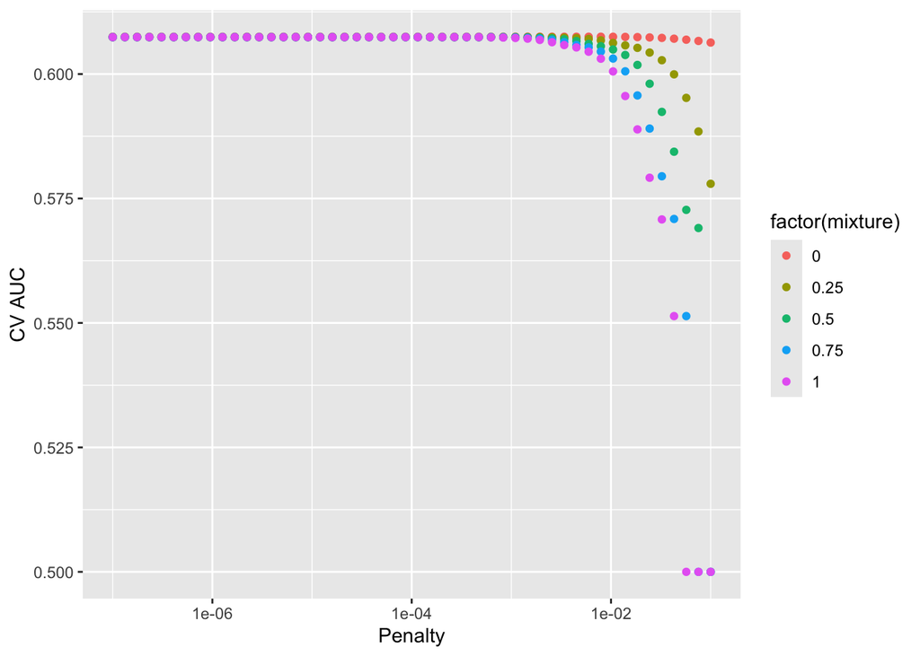

```r
logistic_fit %>%
  collect_metrics() %>%
  filter(.metric == "roc_auc") %>%
  ggplot(mapping = aes(x = penalty, y = mean, color = factor(mixture))) +
  geom_point() +
  labs(x = "Penalty", y = "CV AUC") +
  scale_x_log10()
```

```r
logistic_fit %>%
  show_best(metric = "roc_auc")
```

```
# A tibble: 5 × 8
      penalty mixture .metric .estimator  mean     n std_err .config
        <dbl>   <dbl> <chr>   <chr>      <dbl> <int>   <dbl> <chr>
1 0.00791           0 roc_auc binary     0.607     5 0.00233 Preprocessor1_Mode…
2 0.0000001         0 roc_auc binary     0.607     5 0.00234 Preprocessor1_Mode…
3 0.000000133       0 roc_auc binary     0.607     5 0.00234 Preprocessor1_Mode…
4 0.000000176       0 roc_auc binary     0.607     5 0.00234 Preprocessor1_Mode…
5 0.000000233       0 roc_auc binary     0.607     5 0.00234 Preprocessor1_Mode…
```

```r
best_logistic = logistic_fit %>%
  select_best(metric = "roc_auc")

best_logistic
```

```
# A tibble: 1 × 3
  penalty mixture .config
    <dbl>   <dbl> <chr>
1 0.00791       0 Preprocessor1_Model041
```

**Tuning and Training of Boosting Model**

```r
boosting_recipe = recipe(data = training_data,
                         los_long ~ .) %>%
  step_impute_mean(potassium) %>%
  step_impute_mean(white_blood_cell_count) %>%
  step_impute_mean(glucose) %>%
  step_impute_mean(chloride) %>%
  step_impute_mean(hematocrit) %>%
  step_impute_mean(sodium) %>%
  step_impute_mean(creatinine) %>%
  step_impute_mean(bicarbonate) %>%
  step_impute_mean(heart_rate) %>%
  step_impute_mean(body_temperature) %>%
  step_impute_mean(`diastolic_non-invasive_blood_pressure`) %>%
  step_impute_mean(respiratory_rate) %>%
  step_impute_mean(`systolic_non-invasive_blood_pressure`) %>%
  step_impute_mode(insurance) %>%
  step_impute_mode(marital_status) %>%
  step_dummy(all_nominal_predictors()) %>%
  step_zv(all_numeric_predictors())
```

```r
boosting_model = boost_tree(mode = "classification",
                            trees = 1000,
                            tree_depth = tune(),
                            learn_rate = tune()) %>%
  set_engine("xgboost")
```

```r
boosting_workflow = workflow() %>%
  add_recipe(boosting_recipe) %>%
  add_model(boosting_model)
```

```r
boosting_grid = grid_regular(tree_depth(range = c(1L, 3L)),
                              learn_rate(range = c(-4, 4),
                              trans = log10_trans()),
                              levels = c(2, 10))
```

```r
boosting_fit = boosting_workflow %>%
  tune_grid(resamples = folds, grid = boosting_grid,
            metrics = metric_set(roc_auc, accuracy),
            control = control_stack_grid())
```

```
ℹ The workflow being saved contains a recipe, which is 6.41 Mb in ℹ memory. If
this was not intentional, please set the control setting ℹ `save_workflow =
FALSE`.
```

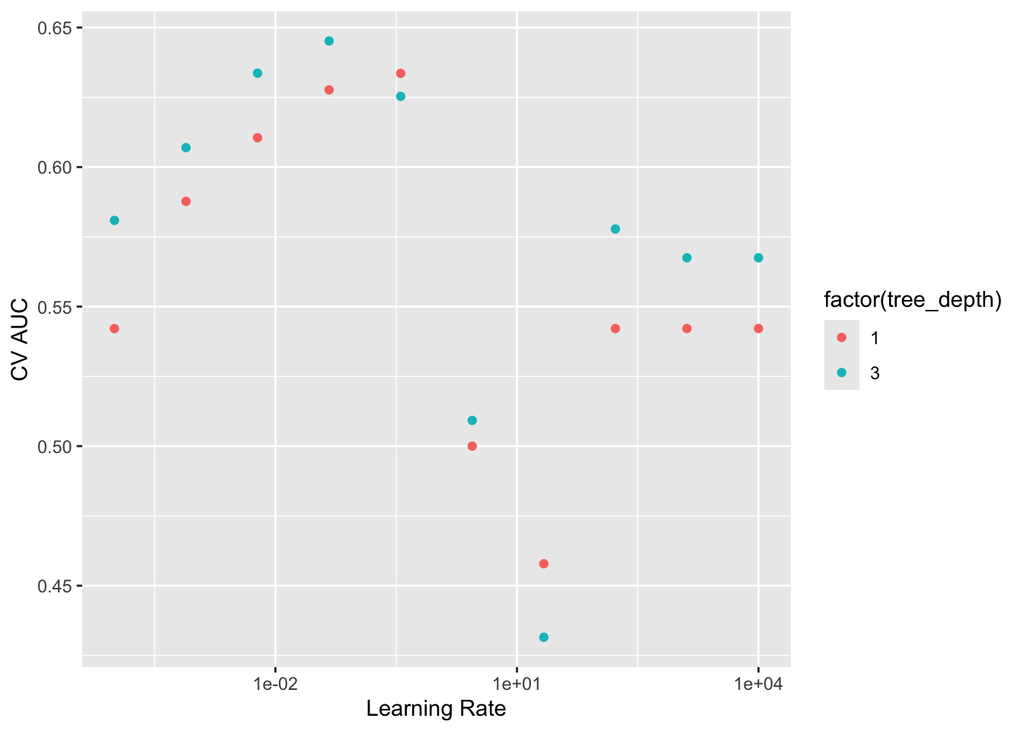

```r
boosting_fit %>%
  collect_metrics() %>%
  filter(.metric == "roc_auc") %>%
  ggplot(mapping = aes(x = learn_rate, y = mean, color = factor(tree_depth))) +
  geom_point() +
  labs(x = "Learning Rate", y = "CV AUC") +
  scale_x_log10()
```

```r
boosting_fit %>%
  show_best(metric = "roc_auc")
```

```
# A tibble: 5 × 8
  tree_depth learn_rate .metric .estimator  mean     n std_err .config
       <int>      <dbl> <chr>   <chr>      <dbl> <int>   <dbl> <chr>
1          3    0.0464  roc_auc binary     0.645     5 0.00252 Preprocessor1_Mo…
2          3    0.00599 roc_auc binary     0.634     5 0.00291 Preprocessor1_Mo…
3          1    0.359   roc_auc binary     0.634     5 0.00200 Preprocessor1_Mo…
4          1    0.0464  roc_auc binary     0.628     5 0.00156 Preprocessor1_Mo…
5          3    0.359   roc_auc binary     0.625     5 0.00281 Preprocessor1_Mo…
```

```r
best_boosting = boosting_fit %>%
  select_best(metric = "roc_auc")

best_boosting
```

```
# A tibble: 1 × 3
  tree_depth learn_rate .config
       <int>      <dbl> <chr>
1          3     0.0464 Preprocessor1_Model08
```

**Tuning and Training for Random Forest**

```r
random_forest_recipe = recipe(data = training_data,
                         los_long ~ .) %>%
  step_impute_mean(potassium) %>%
  step_impute_mean(white_blood_cell_count) %>%
  step_impute_mean(glucose) %>%
  step_impute_mean(chloride) %>%
  step_impute_mean(hematocrit) %>%
  step_impute_mean(sodium) %>%
  step_impute_mean(creatinine) %>%
  step_impute_mean(bicarbonate) %>%
  step_impute_mean(heart_rate) %>%
  step_impute_mean(body_temperature) %>%
  step_impute_mean(`diastolic_non-invasive_blood_pressure`) %>%
  step_impute_mean(respiratory_rate) %>%
  step_impute_mean(`systolic_non-invasive_blood_pressure`) %>%
  step_impute_mode(insurance) %>%
  step_impute_mode(marital_status) %>%
  step_zv(all_numeric_predictors())
```

```r
random_forest_model = rand_forest(mode = "classification",
                mtry = tune(),
                trees = tune()) %>%
  set_engine("ranger")
```

```r
random_forest_workflow = workflow() %>%
  add_recipe(random_forest_recipe) %>%
  add_model(random_forest_model)
```

```r
random_forest_grid = grid_regular(trees(range = c(450L, 650L)),
                        mtry(range = c(1L, 3L)),
                        levels = c(5, 5))
```

```r
random_forest_fit = random_forest_workflow %>% tune_grid(resamples = folds,
                                     grid = random_forest_grid,
                                     metrics = metric_set(roc_auc, accuracy),
                                     control = control_stack_grid())
```

```
ℹ The workflow being saved contains a recipe, which is 6.38 Mb in ℹ memory. If
this was not intentional, please set the control setting ℹ `save_workflow =
FALSE`.
```

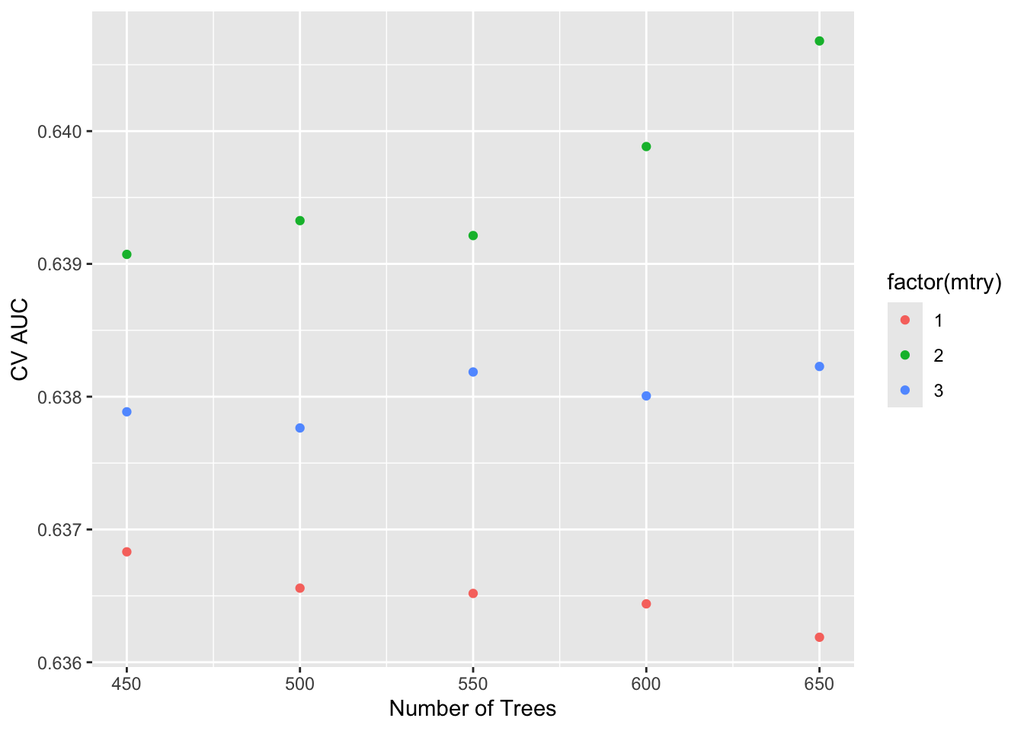

```r
random_forest_fit %>%
  collect_metrics() %>%
  filter(.metric == "roc_auc") %>%
  ggplot(mapping = aes(x = trees, y = mean, color = factor(mtry))) +
  geom_point() +
  labs(x = "Number of Trees", y = "CV AUC")
```

```r
random_forest_fit %>% show_best(metric = "roc_auc")
```

```
# A tibble: 5 × 8
   mtry trees .metric .estimator  mean     n std_err .config
  <int> <int> <chr>   <chr>      <dbl> <int>   <dbl> <chr>
1     2   650 roc_auc binary     0.641     5 0.00266 Preprocessor1_Model10
2     2   600 roc_auc binary     0.640     5 0.00256 Preprocessor1_Model09
3     2   500 roc_auc binary     0.639     5 0.00252 Preprocessor1_Model07
4     2   550 roc_auc binary     0.639     5 0.00266 Preprocessor1_Model08
5     2   450 roc_auc binary     0.639     5 0.00220 Preprocessor1_Model06
```

```r
best_random_forest = random_forest_fit %>%
  select_best(metric = "roc_auc")

best_random_forest
```

```
# A tibble: 1 × 3
   mtry trees .config
  <int> <int> <chr>
1     2   650 Preprocessor1_Model10
```

**Tuning and Training for Stacking**

```r
stacking_model = stacks() %>%
  add_candidates(logistic_fit) %>%
  add_candidates(boosting_fit) %>%
  add_candidates(random_forest_fit) %>%
  blend_predictions(penalty = 10^(-4:4),
                    metrics = c("roc_auc", "accuracy")) %>%
  fit_members()
```

```r
stacking_model
```

```
── A stacked ensemble model ─────────────────────────────────────


Out of 113 possible candidate members, the ensemble retained 7.

Penalty: 0.01.

Mixture: 1.


The 7 highest weighted member classes are:
```

```
# A tibble: 7 × 3
  member                           type        weight
  <chr>                            <chr>        <dbl>
1 .pred_YES_boosting_fit_1_08      boost_tree  2.29
2 .pred_YES_random_forest_fit_1_10 rand_forest 1.54
3 .pred_YES_random_forest_fit_1_09 rand_forest 0.350
4 .pred_YES_random_forest_fit_1_07 rand_forest 0.157
5 .pred_YES_boosting_fit_1_10      boost_tree  0.136
6 .pred_YES_random_forest_fit_1_13 rand_forest 0.0804
7 .pred_YES_random_forest_fit_1_11 rand_forest 0.0359
```

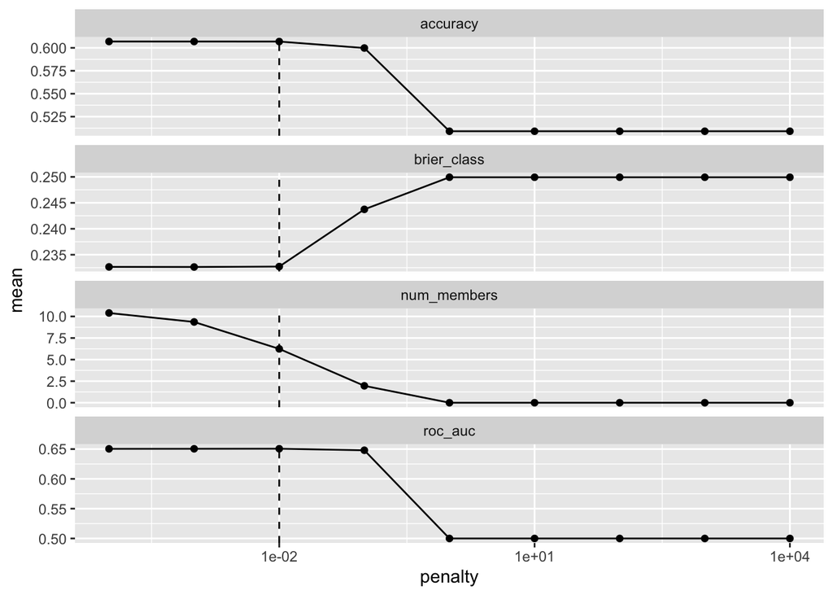

```r
autoplot(stacking_model)
```

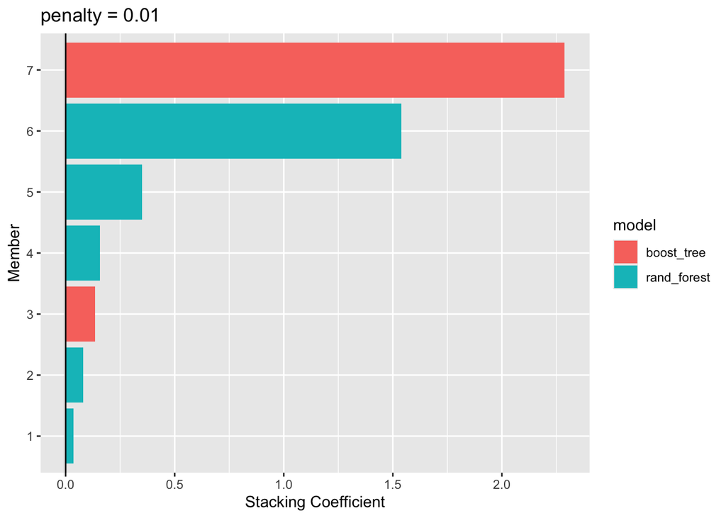

```r
# Plot shows impact of each model in the stacking model

autoplot(stacking_model, type = "weights")
```

4. Compare model classification performance on the test set. Report both the area under ROC curve and accuracy for each machine learning algorithm and the model stacking. Interpret the results. What are the most important features in predicting long ICU stays? How do the models compare in terms of performance and interpretability?

**Logistic Regression Model for Testing Data**

```r
logistic_final_workflow = logistic_workflow %>%
  finalize_workflow(best_logistic)
```

```r
logistic_final_workflow %>%
  last_fit(data_split) %>%
  collect_metrics()
```

```
# A tibble: 3 × 4
  .metric     .estimator .estimate .config
  <chr>       <chr>          <dbl> <chr>
1 accuracy    binary         0.575 Preprocessor1_Model1
2 roc_auc     binary         0.604 Preprocessor1_Model1
3 brier_class binary         0.242 Preprocessor1_Model1
```

**Boosting Model for Testing Data**

```r
boosting_final_workflow = boosting_workflow %>%
  finalize_workflow(best_boosting)
```

```r
boosting_final_workflow %>%
  last_fit(data_split) %>%
  collect_metrics()
```

```
# A tibble: 3 × 4
  .metric     .estimator .estimate .config
  <chr>       <chr>          <dbl> <chr>
1 accuracy    binary         0.602 Preprocessor1_Model1
2 roc_auc     binary         0.642 Preprocessor1_Model1
3 brier_class binary         0.235 Preprocessor1_Model1
```

**Random Forest Model for Testing Data**

```r
random_forest_final_workflow = random_forest_workflow %>%
  finalize_workflow(best_random_forest)
```

```r
random_forest_final_workflow %>%
  last_fit(data_split) %>%
  collect_metrics()
```

```
# A tibble: 3 × 4
  .metric     .estimator .estimate .config
  <chr>       <chr>          <dbl> <chr>
1 accuracy    binary         0.598 Preprocessor1_Model1
2 roc_auc     binary         0.636 Preprocessor1_Model1
3 brier_class binary         0.236 Preprocessor1_Model1
```

**Stacking Model for Testing Data**

```r
los_long_predictions = testing_data %>%
  bind_cols(predict(stacking_model, ., type = "prob")) %>%
  print(width = Inf)
```

```
# A tibble: 47,223 × 24
   first_careunit                                   admission_type
   <fct>                                            <fct>
 1 Medical Intensive Care Unit (MICU)               EW EMER.
 2 Medical/Surgical Intensive Care Unit (MICU/SICU) EW EMER.
 3 Cardiac Vascular Intensive Care Unit (CVICU)     SURGICAL SAME DAY ADMISSION
 4 Other                                            OBSERVATION ADMIT
 5 Medical Intensive Care Unit (MICU)               EW EMER.
 6 Medical/Surgical Intensive Care Unit (MICU/SICU) EW EMER.
 7 Medical Intensive Care Unit (MICU)               EW EMER.
 8 Other                                            URGENT
 9 Other                                            EW EMER.
10 Cardiac Vascular Intensive Care Unit (CVICU)     OBSERVATION ADMIT
   admission_location     insurance marital_status race  gender age_intime
   <fct>                  <fct>     <fct>          <fct> <fct>       <int>
```

[output cut: 59 more lines]

```r
yardstick::roc_auc(los_long_predictions, truth = los_long,
                   contains(".pred_No"))
```

```
# A tibble: 1 × 3
  .metric .estimator .estimate
  <chr>   <chr>          <dbl>
1 roc_auc binary         0.647
```

```r
los_long_predictions = los_long_predictions %>%
  mutate(.pred_class = as.factor(ifelse(.pred_YES > .pred_NO, "YES", "NO")))

yardstick::accuracy(los_long_predictions, truth = los_long,
                   estimate = .pred_class)
```

```
# A tibble: 1 × 3
  .metric  .estimator .estimate
  <chr>    <chr>          <dbl>
1 accuracy binary         0.606
```

```r
xgb.importance(model = boosting_final_workflow %>%
  last_fit(data_split) %>%
  extract_fit_engine())
```

```
                                                            Feature
                                                             <char>
 1:                                                body_temperature
 2:                            systolic_non-invasive_blood_pressure
 3:                                                respiratory_rate
 4:                                                      age_intime
 5:                                                      hematocrit
 6:                       admission_location_TRANSFER.FROM.HOSPITAL
 7:                                                      heart_rate
 8:                           diastolic_non-invasive_blood_pressure
 9:                                          white_blood_cell_count
10:                                                      creatinine
11: first_careunit_Medical.Surgical.Intensive.Care.Unit..MICU.SICU.
12:                                                        chloride
13:                                            first_careunit_Other
```

[output cut: 63 more lines]

The top 3 most important features to predict whether length of stay is long according to the boosting model are: body temperature, systolic non-invasive blood pressure, and respiratory rate.

The Stacked Model seemed to have the best performance in terms of both AUC and accuracy compared to each of the models individually. While the AUC value was around the same for the Stacked Model alongside the Boosting and Random Forest Model, its accuracy was better. The Logistic Model seemed to have the worst performance. Its AUC and accuracy values were the lowest compared to the values of the other models.

In terms of interpretability, I would say that none of these models seemed to be that great at predicting if the length of stay is long or not. A coin toss has a probability of 0.50, so an AUC or accuracy value of around 0.6 isn’t too impressive in comparison.